# Assignment 1

Justine Lang

2023-03-27

```r
knitr::opts_chunk$set(echo = TRUE, warning = FALSE, message = FALSE)

library(here)
library(tidyverse)
library(janitor)
library(vegan)
library(tidyr)
library(dplyr)
library(kableExtra)
```

```r
#read presence-absence data

grasspa <- read.csv(here("data", "grassland_dat_pa.csv"),header=TRUE)

padat <- grasspa[,4:40] #plot x species P/A matrix in format for vegan analysis
```

```r
#read cover data
    grasscov <- read.csv(here("data", "grassland_dat_cover.csv"),header=TRUE)
    covdat <- grasscov[,4:40]   #plot x species cover matrix in format for vegan analysis
```

```r
### read in 2023 data

grasspa_2023 <- read_csv(here("data", "grassland_dat_pa_2023.csv"))
padat_2023 <- grasspa_2023[,4:27]

grasscov_2023 <- read_csv(here("data", "grassland_dat_cover_2023.csv"))
covdat_2023 <- grasscov_2023[,4:27]
```

# 1. Species Richness

## 1a)

### Accumulation Curves - 10 Subplots (2019 & 2023)

```r
#create exact species accumulation curves for 4 plots using 10 subplots (2019)
    accum1 <- specaccum(padat[1:10,])   #plot 1, subplots 1-10
    accum2 <- specaccum(padat[13:22,])  #plot 2, subplots 1-10
    accum3 <- specaccum(padat[25:34,])  #plot 3, subplots 1-10
    accum4 <- specaccum(padat[37:46,])  #plot 4, subplots 1-10
```

```r
#create exact species accumulation curves for 3 plots using 10 subplots (2023)
    accum1_23 <- specaccum(padat_2023[1:10,])   #plot 1, subplots 1-10
    accum2_23 <- specaccum(padat_2023[13:22,])  #plot 2, subplots 1-10
    accum3_23 <- specaccum(padat_2023[24:33,])  #plot 3, subplots 1-10
```

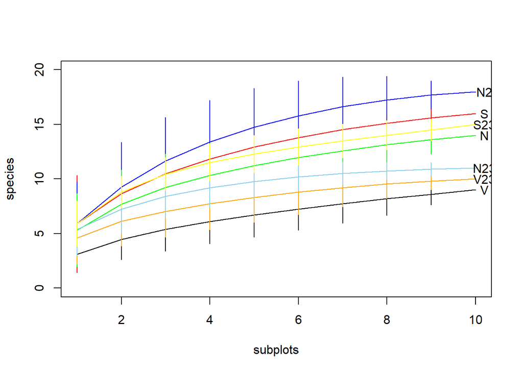

Figure 1: Plant species accumulation curves for 2019 and 2023 utilizing 10 subplots per plot. 4 plots were sampled in 2019. 3 plots were sampled in 2023. Plots were located in the valley (V) and on the north (N and N2) and south (S) slopes.

```r
#plot accumulation curves for each plot
    plot(accum1,ylim=c(0,20),xlab="subplots",ylab="species")
        lines(accum2,col="red")
        lines(accum3,col="blue")
        lines(accum4,col="green")
        lines(accum1_23, col = "orange")
        lines(accum2_23, col = "skyblue")
        lines(accum3_23, col = "yellow")
        text(10.2,9,"V")    #valley plot
        text(10.2,14,"N") #North plot
        text(10.2,16,"S") #South plot
        text(10.2,18,"N2") #second north plot
        text(10.2, 10, "V23") ### V 2023 plot
        text(10.2, 11, "N23") ### N 2023 plot
        text(10.2, 15, "S23") ### S 2023 plot
```

### Accumulation Curves - 12 Subplots (2019 & 2023)

```r
#create exact species accumulation curves for 4 plots using 12 subplots (2019)
    accum1b <- specaccum(padat[1:12,])  #plot 1, subplots 1-10
    accum2b <- specaccum(padat[13:24,]) #plot 2, subplots 1-10
    accum3b <- specaccum(padat[25:36,]) #plot 3, subplots 1-10
    accum4b <- specaccum(padat[37:48,]) #plot 4, subplots 1-10
```

```r
#create exact species accumulation curves for 3 plots using 11-12 subplots (2023)
    accum1b_23 <- specaccum(padat_2023[1:12,])  #plot 1, subplots 1-10
    accum2b_23 <- specaccum(padat_2023[13:23,]) #plot 2, subplots 1-10
    accum3b_23 <- specaccum(padat_2023[24:34,]) #plot 3, subplots 1-10
```

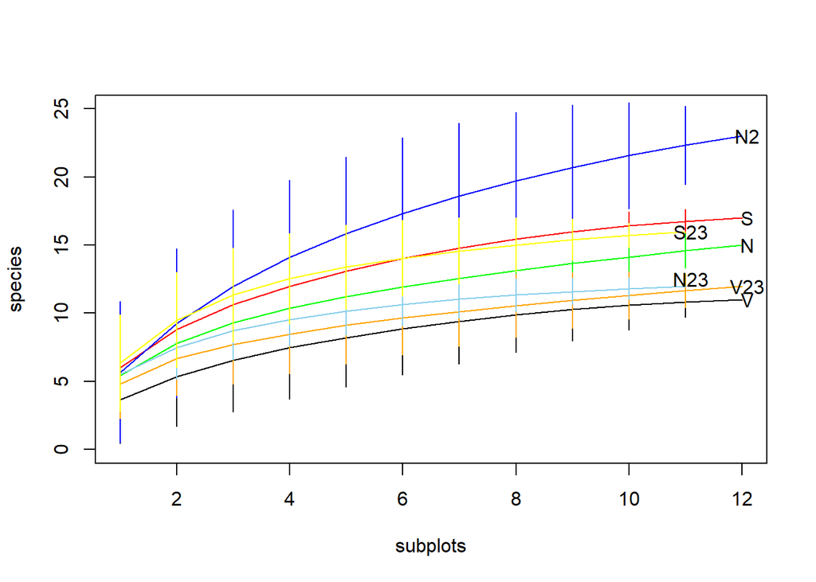

Figure 2: Plant species accumulation curves for 2019 and 2023 utilizing 12 subplots per plot. 4 plots were sampled in 2019. 3 plots were sampled in 2023. Plots were located in the valley (V) and on the north (N and N2) and south (S) slopes.

```r
#plot accumulation curves for each plot, with subplots 11 and 12
    plot(accum1b,ylim=c(0,25),xlab="subplots",ylab="species")
        lines(accum2b,col="red")
        lines(accum3b,col="blue")
        lines(accum4b,col="green")
        lines(accum1b_23, col = "orange")
        lines(accum2b_23, col = "skyblue")
        lines(accum3b_23, col = "yellow")
        text(12.1,11,"V")   #valley plot
        text(12.1,15,"N") #North plot
        text(12.1,17,"S") #South plot
        text(12.1,23,"N2") #second north plot
        text(12.1, 12, "V23") ### valley 2023 plot
        text(11.1, 12.5, "N23") ### north 2023 plot
        text(11.1, 16, "S23") ### south 2023 plot
```

## 1b)

### Single Curve - 40 Subplots

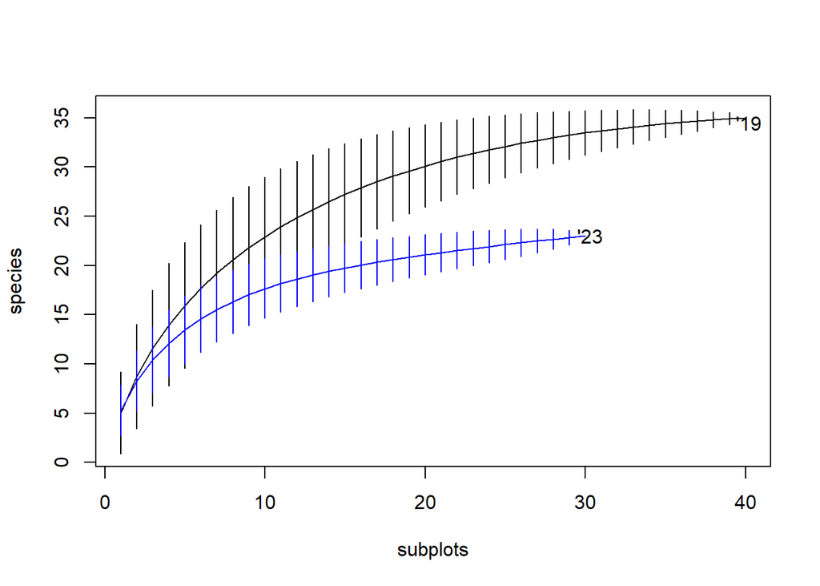

Figure 3: The accumulated number of plant species found in all 40 (2019) and 30 (2023) subplots.

```r
#plot single accumulation curve using 40 (2019) and 30 (2023) subplots
accum_allsubplots <- specaccum(padat[c(1:10,13:22,25:34,37:46),])
accum_allsubplots_23 <- specaccum(padat_2023[c(1:10, 13:22, 24:33),])

    plot(accum_allsubplots,xlab="subplots",ylab="species")
    lines(accum_allsubplots_23, col="blue")
    text(40.2, 34.5, "'19")
    text(30.3, 23, "'23")
```

### Single Curve - 48 Subplots

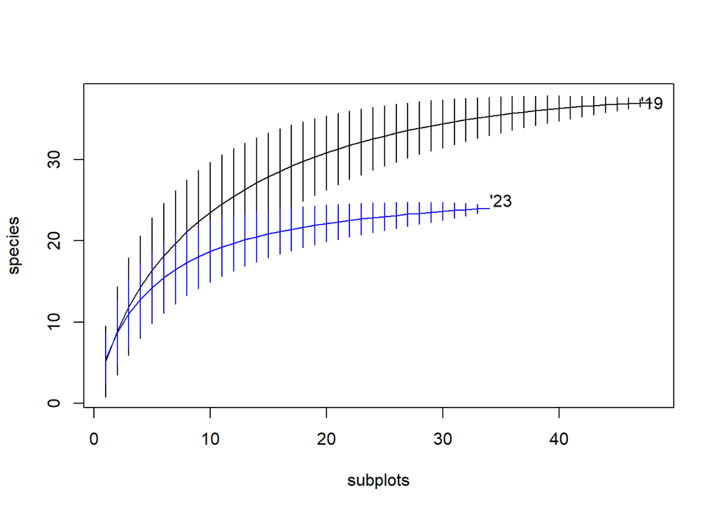

Figure 4: The accumulated number of plant species found in all 48 (2019) and 34 (2023) subplots.

```r
#plot single accumulation curve using 48 (2019) and 34 (2023) subplots
accum_allsubplotsb <- specaccum(padat[c(1:12,13:24,25:36,37:48),])
accum_allsubplotsb_23 <- specaccum(padat_2023[c(1:12, 13:23, 24:34),])

    plot(accum_allsubplotsb,xlab="subplots",ylab="species")
    lines(accum_allsubplotsb_23, col="blue")
    text(48, 37, "'19")
    text(35, 25, "'23")
```

### Chao Estimate

```r
#calculate Bray-Curtis dissimilarity between plots
#First, aggregate subplot data
    p1 <- apply(padat[1:12,],2,max)
    p2 <- apply(padat[13:24,],2,max)
    p3 <- apply(padat[25:36,],2,max)
    p4 <- apply(padat[37:48,],2,max)
# create new matrix to calculate pairwise plot dissimilarity
    plots_spp <- rbind(p1,p2,p3,p4)
#produce dissimilarity matrix
    plots_bray_diss <- vegdist(plots_spp,method="bray")
```

**2019**

```r
specpool(plots_spp) %>%
  kable(caption = "Chao Estimate 2019 Data") %>%
  kable_classic(position = "center")
```

Chao Estimate 2019 Data

|  | Species | chao | chao.se | jack1 | jack1.se | jack2 | boot | boot.se | n |
| --- | --- | --- | --- | --- | --- | --- | --- | --- | --- |
| All | 37 | 43.4 | 4.401212 | 49 | 7.937254 | 52 | 43.01562 | 4.944195 | 4 |

**2023**

```r
p1_23 <- apply(padat_2023[1:12,],2,max)
p2_23 <- apply(padat_2023[13:23,],2,max)
p3_23 <- apply(padat_2023[24:34,],2,max)

plots_spp_23 <- rbind(p1_23,p2_23,p3_23)
```

```r
specpool(plots_spp_23) %>%
  kable(caption = "Chao Estimate 2023 Data") %>%
  kable_classic(position = "center")
```

Chao Estimate 2023 Data

|  | Species | chao | chao.se | jack1 | jack1.se | jack2 | boot | boot.se | n |
| --- | --- | --- | --- | --- | --- | --- | --- | --- | --- |
| All | 24 | 30 | 4.743417 | 32 | 5.773503 | 34.66667 | 27.85185 | 3.193787 | 3 |

## 1c)

### Native

```r
### read in species data

species <- read_csv(here("data", "grassland_common_species_ex1.csv"))

# subplots_40 <- padat[c(1:10,13:22,25:34,37:46),]

# accum_all <- specaccum(subplots_40)

# plot_sub <- plot(accum_all, xlab = "subplots", ylab = "species")

native <- species %>%
  filter(Native == 1) %>%
  filter(is.na(Native) == F)

exotic <- species %>%
  filter(Native == 0) %>%
  filter(is.na(Native) == F)

native_wide <- native %>%
  pivot_wider(names_from = Code,
              values_from = Native)

sub_native <- padat %>%
  select(any_of(names(native_wide)))

sub_native_23 <- padat_2023 %>%
  select(any_of(names(native_wide)))
```

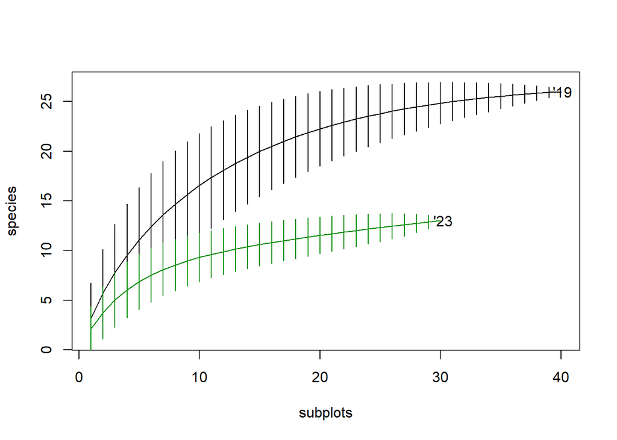

Figure 5: The accumulated number of native plant species found in 40 (2019) and 30 (2023) subplots.

```r
#plot single accumulation curve using 40 subplots for native species

subnative_list <- sub_native[c(1:10,13:22,25:34,37:46),] %>%
  drop_na()

accum_allnative <- specaccum(subnative_list)
accum_allnative_23 <- specaccum(sub_native_23[c(1:10, 13:22, 24:33),])

plot(accum_allnative, xlab="subplots",ylab="species")
lines(accum_allnative_23, col="green4")
text(40.1, 26, "'19")
text(30.2, 13, "'23")
```

**2019**

```r
specpool(sub_native) %>%
  kable(caption = "Chao Estimate 2019 Native Species") %>%
  kable_classic(position = "center")
```

Chao Estimate 2019 Native Species

|  | Species | chao | chao.se | jack1 | jack1.se | jack2 | boot | boot.se | n |
| --- | --- | --- | --- | --- | --- | --- | --- | --- | --- |
| All | 27 | 27.27976 | 0.6689367 | 28.95833 | 1.384751 | 24.3094 | 28.82778 | 1.331086 | 48 |

**2023**

```r
specpool(sub_native_23) %>%
  kable(caption = "Chao Estimate 2023 Native Species") %>%
  kable_classic(position = "center")
```

Chao Estimate 2023 Native Species

|  | Species | chao | chao.se | jack1 | jack1.se | jack2 | boot | boot.se | n |
| --- | --- | --- | --- | --- | --- | --- | --- | --- | --- |
| All | 14 | 14.64706 | 1.274359 | 15.94118 | 1.372619 | 15.08556 | 15.17022 | 0.9153012 | 34 |

## 1d)

### Exotic

```r
exotic_wide <- exotic %>%
  pivot_wider(names_from = Code,
              values_from = Native)

sub_exotic <- padat %>%
  select(any_of(names(exotic_wide)))

sub_exotic_23 <- padat_2023 %>%
  select(any_of(names(exotic_wide)))
```

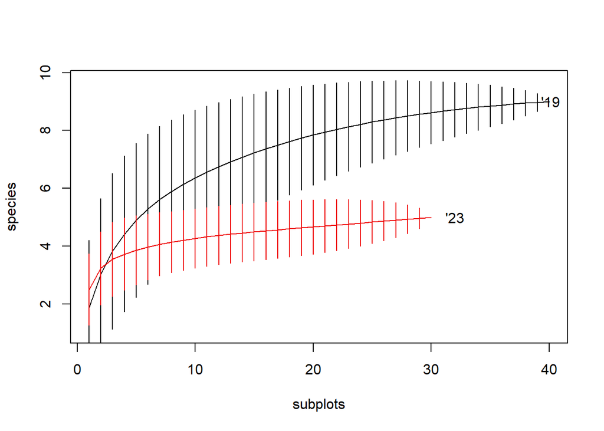

Figure 6: The accumulated number of exotic plant species found in 40 (2019) and 30 (2023) subplots.

```r
#plot single accumulation curve using 40 subplots for exotic species

subexotic_list <- sub_exotic[c(1:10,13:22,25:34,37:46),] %>%
  drop_na()

accum_allexotic <- specaccum(subexotic_list)
accum_allexotic_23 <- specaccum(sub_exotic_23[c(1:10, 13:22, 24:33),])

plot(accum_allexotic, xlab="subplots",ylab="species")
lines(accum_allexotic_23, col="red2")
text(40.1, 9, "'19")
text(32, 5, "'23")
```

**2019**

```r
specpool(sub_exotic) %>%
  kable(caption = "Chao Estimate 2019 Exotic Species") %>%
  kable_classic(position = "center")
```

Chao Estimate 2019 Exotic Species

|  | Species | chao | chao.se | jack1 | jack1.se | jack2 | boot | boot.se | n |
| --- | --- | --- | --- | --- | --- | --- | --- | --- | --- |
| All | 10 | 10.24479 | 0.7172482 | 10.97917 | 0.9791667 | 10.06161 | 10.68892 | 0.7533064 | 48 |

**2023**

```r
specpool(sub_exotic_23) %>%
  kable(caption = "Chao Estimate 2023 Exotic Plants") %>%
  kable_classic(position = "center")
```

Chao Estimate 2023 Exotic Plants

|  | Species | chao | chao.se | jack1 | jack1.se | jack2 | boot | boot.se | n |
| --- | --- | --- | --- | --- | --- | --- | --- | --- | --- |
| All | 5 | 5 | 0.4340603 | 5.970588 | 0.9705882 | 6.911765 | 5.363761 | 0.4819003 | 34 |

**How do accumulation curves and estimated sizes of species pools compare for native compared to exotic species?**

The estimated species pools were similar to the observed species for both native and exotic species. The sizes of the native species pools were larger than the exotic. 27 native species were observed in 2019, which aligns with the Chao estimate of 27 (with Jackknife and Bootstrap estimates ranging from 24-29 species). 14 native species were observed in 2023, similar to the Chao estimate of 15 (with the other estimates ranging from 15-16). 10 exotic species were observed in 2019 and 5 in 2023, which are also very similar to the Chao and other estimates.

The 2019 native species curve increases the most gradually (the slope is steepest between subplots 1 and 10) and is slow to level off (starts to level off around subplot 25 but doesn’t really flatten until between subplots 30 and 40), so there still could have been more species than observed like some of the species pools estimates suggest. The 2023 native species accumulation curve starts to level off a little sooner (steepest between subplots 1 and 5; begins to level off after subplot 10), but follows a similar trend. The 2019 exotic species accumulation curve levels off sooner than the native species one (steepest between subplots 1 and 6) and demonstrates a much wider variability. The 2023 exotic species curve also levels off very quickly (only steepest between subplots 1 and 2).

Ultimately, the accumulated number of native species seemed to increase more steadily with each plot and was larger overall, while the number of exotic species didn’t increase much after a smaller number of plots and was smaller than the number of native species recorded.

# 2. Community Dissimilarity

## 2a)

### Bray-Curtis

**2019**

```r
plots_bray_diss
```

```
##           p1        p2        p3
## p2 0.5000000
## p3 0.4705882 0.6500000
## p4 0.7692308 0.7500000 0.5263158
```

**2023**

```r
plots_bray_diss_23 <- vegdist(plots_spp_23,method="bray")

plots_bray_diss_23
```

```
##       p1_23 p2_23
## p2_23   0.5
## p3_23   0.5   0.5
```

## 2c)

### Native

**2019**

```r
# sub_native_clean <- sub_native

#calculate Bray-Curtis dissimilarity between plots
#First, aggregate subplot data
    p1n <- apply(sub_native[1:10,],2,max)
    p2n <- apply(sub_native[13:22,],2,max)
    p3n <- apply(sub_native[25:34,],2,max)
    p4n <- apply(sub_native[37:46,],2,max)
# create new matrix to calculate pairwise plot dissimilarity
    plots_spp_n <- rbind(p1n,p2n,p3n,p4n)
#produce dissimilarity matrix
plots_bray_diss_n <- vegdist(plots_spp_n,method="bray")
```

```r
plots_bray_diss_n
```

```
##           p1n       p2n       p3n
## p2n 0.5000000
## p3n 0.5238095 0.8260870
## p4n 0.7894737 0.7142857 0.6923077
```

**2023**

```r
#calculate Bray-Curtis dissimilarity between plots
#First, aggregate subplot data
    p1n_23 <- apply(sub_native_23[1:10,],2,max)
    p2n_23 <- apply(sub_native_23[13:22,],2,max)
    p3n_23 <- apply(sub_native_23[24:33,],2,max)

# create new matrix to calculate pairwise plot dissimilarity
    plots_spp_n_23 <- rbind(p1n_23,p2n_23,p3n_23)
#produce dissimilarity matrix
plots_bray_diss_n_23 <- vegdist(plots_spp_n_23,method="bray")
```

```r
plots_bray_diss_n_23
```

```
##           p1n_23    p2n_23
## p2n_23 0.4000000
## p3n_23 1.0000000 0.8181818
```

## 2b)

### Cover Data

**2019**

```r
#Analyze cover data
#Calculate area-weighted cover, total area sampled = 10 *0.25 + 2*2.5 = 7.5 sq m
    p1_cov <- (2.5/7.5)*apply(covdat[1:10,],2,mean) +
            (5/7.5)*apply(covdat[11:12,],2,mean)
    p2_cov <- (2.5/7.5)*apply(covdat[13:22,],2,mean) +
            (5/7.5)*apply(covdat[23:24,],2,mean)
    p3_cov <- (2.5/7.5)*apply(covdat[25:34,],2,mean) +
            (5/7.5)*apply(covdat[35:36,],2,mean)
    p4_cov <- (2.5/7.5)*apply(covdat[37:46,],2,mean) +
            (5/7.5)*apply(covdat[47:48,],2,mean)
```

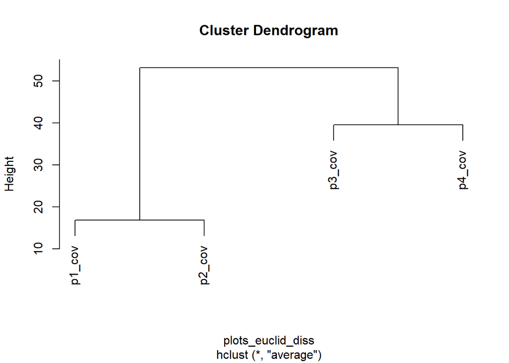

```r
#Analyze plot dissimilarity based on cover
    plots_cov <- rbind(p1_cov,p2_cov,p3_cov,p4_cov)
    plots_euclid_diss <- vegdist(plots_cov,method="euclidean")
    plots_hclust <- hclust(plots_euclid_diss,method="average")      #cluster analysis of plots (contrived)
        plot(plots_hclust)
```

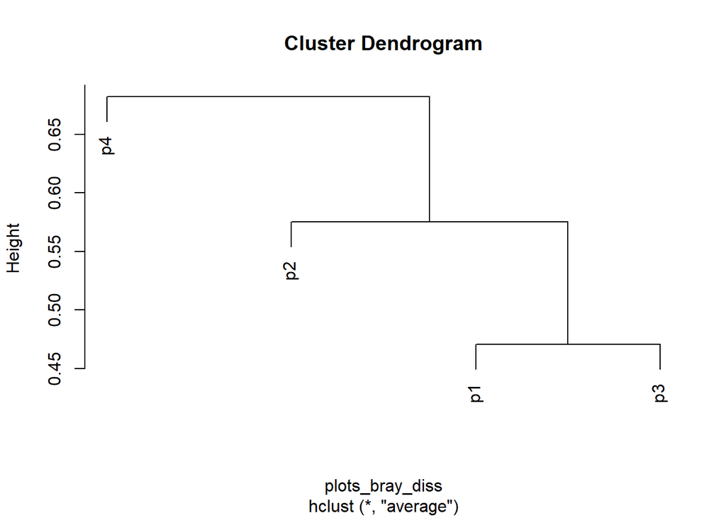

```r
    plots_hclust_pa <- hclust(plots_bray_diss,method="average")
        plot(plots_hclust_pa)
```

**2023**

```r
#Analyze cover data
#Calculate area-weighted cover, total area sampled = 10 *0.25 + 2*2.5 = 7.5 sq m
    p1_cov_23 <- (2.5/7.5)*apply(covdat_2023[1:10,],2,mean) +
            (5/7.5)*apply(covdat_2023[11:12,],2,mean)
    p2_cov_23 <- (2.5/7.5)*apply(covdat_2023[13:22,],2,mean) +
            (2.5/5)*apply(covdat_2023[23,],2,mean)
    p3_cov_23 <- (2.5/7.5)*apply(covdat_2023[24:33,],2,mean) +
            (2.5/5)*apply(covdat_2023[34,],2,mean)
```

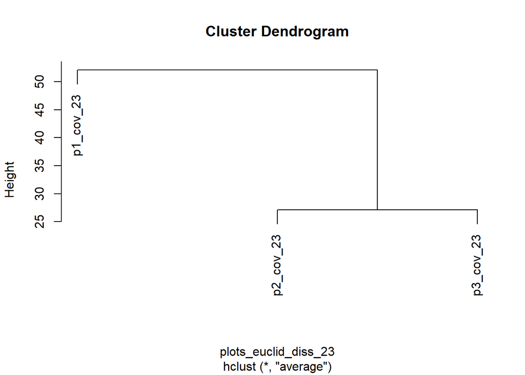

```r
#Analyze plot dissimilarity based on cover
    plots_cov_23 <- rbind(p1_cov_23,p2_cov_23,p3_cov_23)
    plots_euclid_diss_23 <- vegdist(plots_cov_23,method="euclidean")
    plots_hclust_23 <- hclust(plots_euclid_diss_23,method="average")        #cluster analysis of plots (contrived)
        plot(plots_hclust_23)
```

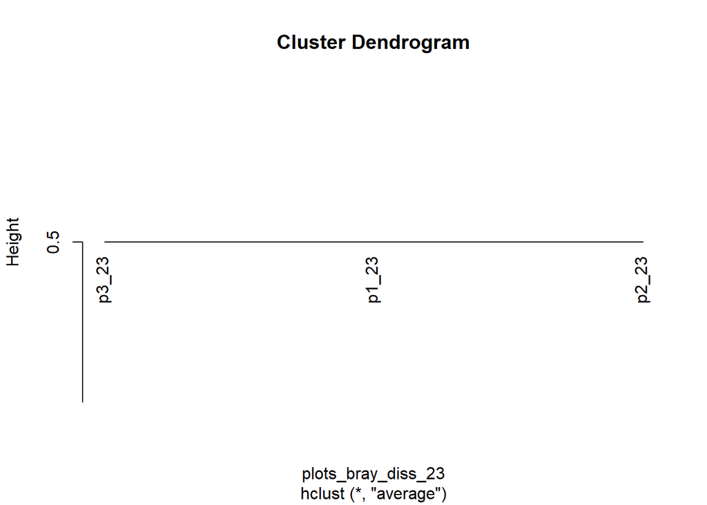

```r
    plots_hclust_pa_23 <- hclust(plots_bray_diss_23,method="average")
        plot(plots_hclust_pa_23)
```

## 2d)

### Native

**2019**

```r
### Filter by native

sub_native_cover <- covdat %>%
  select(any_of(names(native_wide)))
```

```r
#Analyze cover data
#Calculate area-weighted cover, total area sampled = 10 *0.25 + 2*2.5 = 7.5 sq m
    p1_covn <- (2.5/7.5)*apply(sub_native_cover[1:10,],2,mean) +
            (5/7.5)*apply(sub_native_cover[11:12,],2,mean)
    p2_covn <- (2.5/7.5)*apply(sub_native_cover[13:22,],2,mean) +
            (5/7.5)*apply(sub_native_cover[23:24,],2,mean)
    p3_covn <- (2.5/7.5)*apply(sub_native_cover[25:34,],2,mean) +
            (5/7.5)*apply(sub_native_cover[35:36,],2,mean)
    p4_covn <- (2.5/7.5)*apply(sub_native_cover[37:46,],2,mean) +
            (5/7.5)*apply(sub_native_cover[47:48,],2,mean)
```

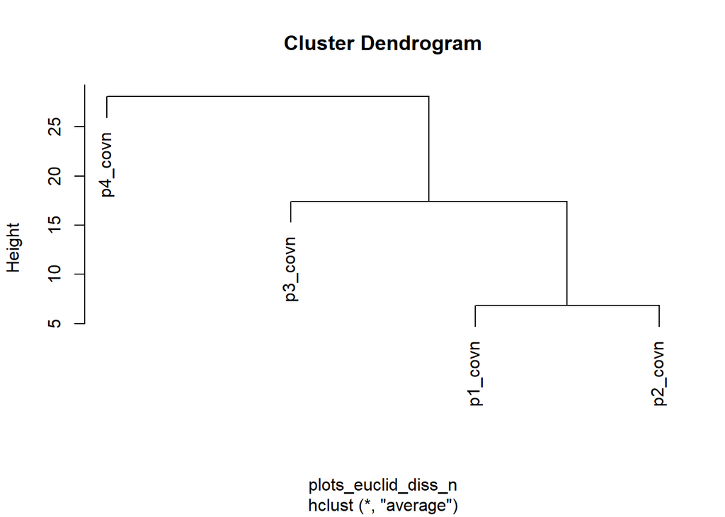

```r
#Analyze plot dissimilarity based on cover
    plots_cov_n <- rbind(p1_covn,p2_covn,p3_covn,p4_covn)
    plots_euclid_diss_n <- vegdist(plots_cov_n,method="euclidean")
    plots_hclust_n <- hclust(plots_euclid_diss_n,method="average")      #cluster analysis of plots (contrived)
        plot(plots_hclust_n)
```

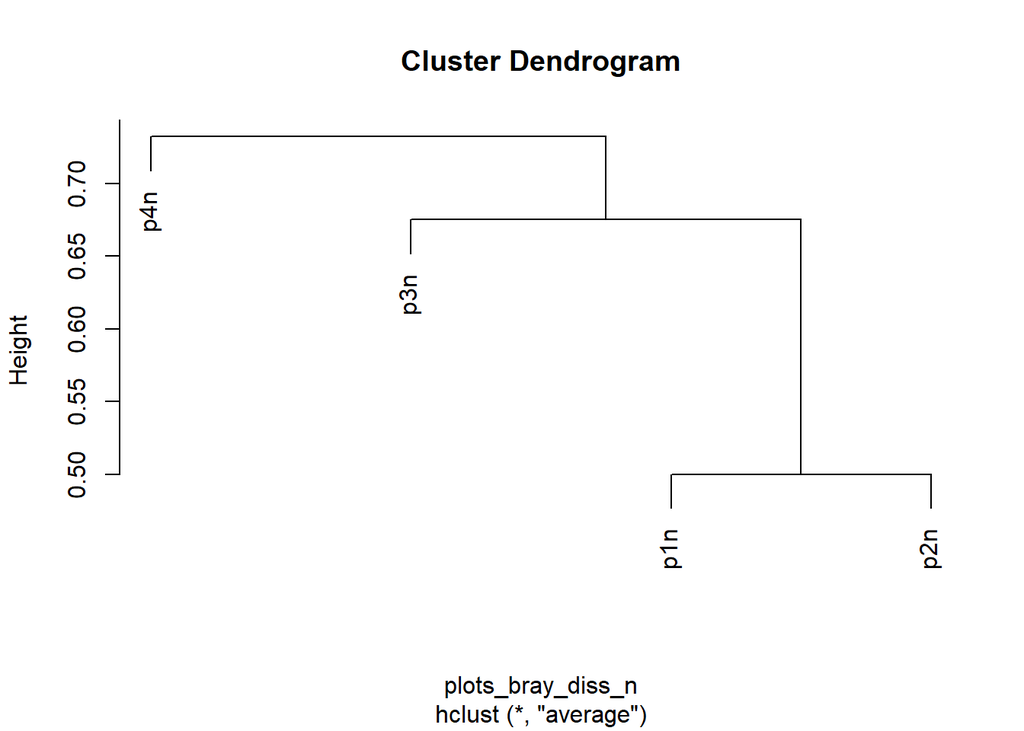

```r
    plots_hclust_pa_n <- hclust(plots_bray_diss_n,method="average")
        plot(plots_hclust_pa_n)
```

**2023**

```r
sub_native_cov_23 <- covdat_2023 %>%
  select(any_of(names(native_wide)))
```

```r
    p1_covn_23 <- (2.5/7.5)*apply(sub_native_cov_23[1:10,],2,mean) +
            (5/7.5)*apply(sub_native_cov_23[11:12,],2,mean)
    p2_covn_23 <- (2.5/5)*apply(sub_native_cov_23[13:22,],2,mean) +
            (2.5/5)*apply(sub_native_cov_23[23,],2,mean)
    p3_covn_23 <- (2.5/5)*apply(sub_native_cov_23[24:33,],2,mean) +
            (2.5/5)*apply(sub_native_cov_23[34,],2,mean)
```

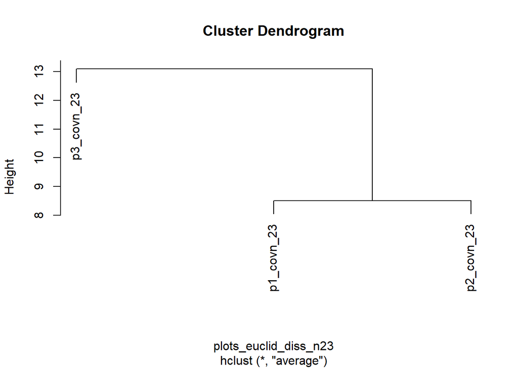

```r
#Analyze plot dissimilarity based on cover
    plots_covn_23 <- rbind(p1_covn_23,p2_covn_23,p3_covn_23)
    plots_euclid_diss_n23 <- vegdist(plots_covn_23,method="euclidean")
    plots_hclust_n23 <- hclust(plots_euclid_diss_n23,method="average")      #cluster analysis of plots (contrived)
        plot(plots_hclust_n23)
```

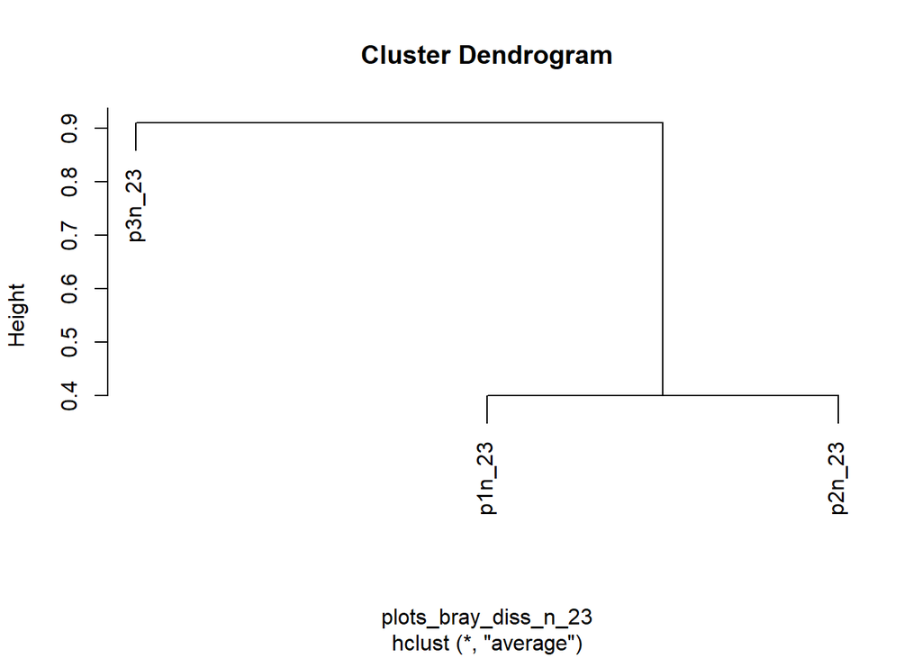

```r
    plots_hclust_pa_n23 <- hclust(plots_bray_diss_n_23,method="average")
        plot(plots_hclust_pa_n23)
```

**Briefly discuss the patterns of plot dissimilarity based on P/A compared to cover data. How do they differ and why?**

For the 2019 cover data, plots 1 (valley) and 2 (south) and plots 3 and 4 (north) were most similar to each other, while for the 2019 P/A data, plots 1 (valley) and 3 (north 2) were most similar to each other and plot 4 (north) sat as an outgroup. For the 2023 cover data, plots 2 (north) and 3 (south) were most similar to each other with plot 1 (valley) as an outgroup, while for the 2023 P/A data, all the plots seemed to have equal levels of similarity.

While P/A data gives a sense of if a species is present in a plot or subplot, cover data gives a better sense of that species abundance and how common it is throughout the plots. For example, we often saw both bromegrass and wildoat in the same subplots, but sometimes the percent cover would consist mostly of one or the other rather than equal of both. For this reason, the plot dissimilarity can differ depending on if you’re looking at P/A or cover since similar P/A doesn’t necessarily mean percent cover is the same.

**Next, briefly discuss patterns of plot dissimilarity based on all species vs. native species only.**

For the 2019 native species cover data, plots 1 (valley) and 2 (south) were most similar, but this time plot 4 (north) sat as an outgroup, while the 2019 native species P/A data followed a similar pattern. For both the 2023 cover data and P/A data, plots 1 (valley) and 2 (north) were the most similar, with the remaining plot 3 (south) as the outgroup.

There were a handful of exotic species that often dominated the percent cover in many subplots, particularly with bromegrass. When considering only native species, the dissimilarity between plots changes. It’s possible that the presence of exotic species could have changed the plot overall dissimilarity between 2019 and 2023, though more sampling may be needed to test that idea.

# 3. Community Evenness

## 3a & 3b)

### Plot Diversity

**2019**

```r
#Analyze plot diversity
    plots_shannon <- diversity(plots_cov,index="shannon")   #shannon H'
    plots_simpson <- diversity(plots_cov,index="simpson")   #simpson diversity
    plots_richness <- specnumber(plots_cov)                 #species richness

    plots_shannon %>%
      kable(caption = "Shannon Diversity 2019") %>%
  kable_classic(position = "center")
```

Shannon Diversity 2019

|  | x |
| --- | --- |
| p1_cov | 0.7253414 |
| p2_cov | 0.6331514 |
| p3_cov | 1.8942098 |
| p4_cov | 1.7282824 |

```r
    plots_simpson %>%
      kable(caption = "Simpson Diversity 2019") %>%
  kable_classic(position = "center")
```

Simpson Diversity 2019

|  | x |
| --- | --- |
| p1_cov | 0.2923519 |
| p2_cov | 0.2305581 |
| p3_cov | 0.7634171 |
| p4_cov | 0.7476111 |

```r
    plots_richness %>%
      kable(caption = "Species Richness 2019") %>%
  kable_classic(position = "center")
```

Species Richness 2019

|  | x |
| --- | --- |
| p1_cov | 11 |
| p2_cov | 17 |
| p3_cov | 23 |
| p4_cov | 15 |

**2023**

```r
#Analyze plot diversity
    plots_shannon_23 <- diversity(plots_cov_23,index="shannon")     #shannon H'
    plots_simpson_23 <- diversity(plots_cov_23,index="simpson") #simpson diversity
    plots_richness_23 <- specnumber(plots_cov_23)                   #species richness

    plots_shannon_23 %>%
      kable(caption = "Shannon Diversity 2023") %>%
  kable_classic(position = "center")
```

Shannon Diversity 2023

|  | x |
| --- | --- |
| p1_cov_23 | 1.466066 |
| p2_cov_23 | 1.300284 |
| p3_cov_23 | 2.220364 |

```r
    plots_simpson_23 %>%
      kable(caption = "Simpson Diversity 2023") %>%
  kable_classic(position = "center")
```

Simpson Diversity 2023

|  | x |
| --- | --- |
| p1_cov_23 | 0.6450357 |
| p2_cov_23 | 0.6077989 |
| p3_cov_23 | 0.8485971 |

```r
    plots_richness_23 %>%
      kable(caption = "Species Richness 2023") %>%
  kable_classic(position = "center")
```

Species Richness 2023

|  | x |
| --- | --- |
| p1_cov_23 | 12 |
| p2_cov_23 | 12 |
| p3_cov_23 | 16 |

## 3c & 3d)

### Native

**2019**

```r
plots_sh_n <- diversity(plots_cov_n,index="shannon")
plots_simp_n <- diversity(plots_cov_n,index="simpson")  #simpson diversity
plots_rich_n <- specnumber(plots_cov_n)                 #species richness

plots_sh_n %>%
  kable(caption = "Native Shannon Diversity 2019") %>%
  kable_classic(position = "center")
```

Native Shannon Diversity 2019

|  | x |
| --- | --- |
| p1_covn | 1.567242 |
| p2_covn | 1.767525 |
| p3_covn | 1.344058 |
| p4_covn | 1.619531 |

```r
plots_simp_n %>%
  kable(caption = "Native Simpson Diversity 2019") %>%
  kable_classic(position = "center")
```

Native Simpson Diversity 2019

|  | x |
| --- | --- |
| p1_covn | 0.7471782 |
| p2_covn | 0.8000000 |
| p3_covn | 0.5650715 |
| p4_covn | 0.7107577 |

```r
plots_rich_n %>%
  kable(caption = "Native Species Richness 2019") %>%
  kable_classic(position = "center")
```

Native Species Richness 2019

|  | x |
| --- | --- |
| p1_covn | 9 |
| p2_covn | 9 |
| p3_covn | 17 |
| p4_covn | 13 |

**2023**

```r
plots_sh_n23 <- diversity(plots_covn_23,index="shannon")
plots_simp_n23 <- diversity(plots_covn_23,index="simpson")  #simpson diversity
plots_rich_n23 <- specnumber(plots_covn_23)                 #species richness

plots_sh_n23 %>%
  kable(caption = "Native Shannon Diversity 2023") %>%
  kable_classic(position = "center")
```

Native Shannon Diversity 2023

|  | x |
| --- | --- |
| p1_covn_23 | 1.443437 |
| p2_covn_23 | 1.084861 |
| p3_covn_23 | 1.755631 |

```r
plots_simp_n23 %>%
  kable(caption = "Native Simpson Diversity 2023") %>%
  kable_classic(position = "center")
```

Native Simpson Diversity 2023

|  | x |
| --- | --- |
| p1_covn_23 | 0.7182867 |
| p2_covn_23 | 0.5919421 |
| p3_covn_23 | 0.7856886 |

```r
plots_rich_n23 %>%
  kable(caption = "Native Species Richness 2023") %>%
  kable_classic(position = "center")
```

Native Species Richness 2023

|  | x |
| --- | --- |
| p1_covn_23 | 8 |
| p2_covn_23 | 5 |
| p3_covn_23 | 8 |

### Exotic

**2019**

```r
sub_exotic_cover <- covdat %>%
  select(any_of(names(exotic_wide)))
```

```r
p1_covex <- (2.5/7.5)*apply(sub_exotic_cover[1:10,],2,mean) +
            (5/7.5)*apply(sub_exotic_cover[11:12,],2,mean)
    p2_covex <- (2.5/7.5)*apply(sub_exotic_cover[13:22,],2,mean) +
            (5/7.5)*apply(sub_exotic_cover[23:24,],2,mean)
    p3_covex <- (2.5/7.5)*apply(sub_exotic_cover[25:34,],2,mean) +
            (5/7.5)*apply(sub_exotic_cover[35:36,],2,mean)
    p4_covex <- (2.5/7.5)*apply(sub_exotic_cover[37:46,],2,mean) +
            (5/7.5)*apply(sub_exotic_cover[47:48,],2,mean)

    plots_cov_ex <- rbind(p1_covex,p2_covex,p3_covex,p4_covex)
```

```r
plots_sh_ex <- diversity(plots_cov_ex,index="shannon")  #shannon H'
plots_simp_ex <- diversity(plots_cov_ex,index="simpson")    #simpson diversity
plots_rich_ex <- specnumber(plots_cov_ex)                   #species richness

plots_sh_ex %>%
  kable(caption = "Exotic Shannon Diversity 2019") %>%
  kable_classic(position = "center")
```

Exotic Shannon Diversity 2019

|  | x |
| --- | --- |
| p1_covex | 0.1004368 |
| p2_covex | 0.4283982 |
| p3_covex | 1.0347253 |
| p4_covex | 0.3265132 |

```r
plots_simp_ex %>%
  kable(caption = "Exotic Simpson Diversity 2019") %>%
  kable_classic(position = "center")
```

Exotic Simpson Diversity 2019

|  | x |
| --- | --- |
| p1_covex | 0.0403869 |
| p2_covex | 0.1717324 |
| p3_covex | 0.4918982 |
| p4_covex | 0.1810423 |

```r
plots_rich_ex %>%
  kable(caption = "Exotic Species Richess 2019") %>%
  kable_classic(position = "center")
```

Exotic Species Richess 2019

|  | x |
| --- | --- |
| p1_covex | 2 |
| p2_covex | 8 |
| p3_covex | 6 |
| p4_covex | 2 |

**2023**

```r
sub_exotic_cover23 <- covdat_2023 %>%
  select(any_of(names(exotic_wide)))
```

```r
p1_cov_ex23 <- (2.5/7.5)*apply(sub_exotic_cover23[1:10,],2,mean) +
            (5/7.5)*apply(sub_exotic_cover23[11:12,],2,mean)
    p2_cov_ex23 <- (2.5/5)*apply(sub_exotic_cover23[13:22,],2,mean) +
            (2.5/5)*apply(sub_exotic_cover23[23,],2,mean)
    p3_cov_ex23 <- (2.5/5)*apply(sub_exotic_cover23[24:33,],2,mean) +
            (2.5/5)*apply(sub_exotic_cover23[34,],2,mean)

        plots_cov_ex23 <- rbind(p1_cov_ex23,p2_cov_ex23,p3_cov_ex23)
```

```r
plots_sh_ex23 <- diversity(plots_cov_ex23,index="shannon")  #shannon H'
plots_simp_ex23 <- diversity(plots_cov_ex23,index="simpson")    #simpson diversity
plots_rich_ex23 <- specnumber(plots_cov_ex23)                   #species richness

plots_sh_ex23 %>%
  kable(caption = "Exotic Shannon Diversity 2023") %>%
  kable_classic(position = "center")
```

Exotic Shannon Diversity 2023

|  | x |
| --- | --- |
| p1_cov_ex23 | 0.6589236 |
| p2_cov_ex23 | 0.8174834 |
| p3_cov_ex23 | 1.2931162 |

```r
plots_simp_ex23 %>%
  kable(caption = "Exotic Simpson Diversity 2023") %>%
  kable_classic(position = "center")
```

Exotic Simpson Diversity 2023

|  | x |
| --- | --- |
| p1_cov_ex23 | 0.3861960 |
| p2_cov_ex23 | 0.5132279 |
| p3_cov_ex23 | 0.6711015 |

```r
plots_rich_ex23 %>%
  kable(caption = "Exotic Species Richness 2023") %>%
  kable_classic(position = "center")
```

Exotic Species Richness 2023

|  | x |
| --- | --- |
| p1_cov_ex23 | 3 |
| p2_cov_ex23 | 3 |
| p3_cov_ex23 | 5 |

**How does the rank order of diversity among plots vary depending on whether you use the Shannon or Simpson index?**

For 2019, the rank order from highest to lowest based on the Shannon index was plot 3, plot 4, plot 1, plot 2. Based on the Simpson index, the rank was the same. For 2023, similarly, the rank order based on the Shannon index was plot 3, plot 1, plot 2. Based on the Simpson index, the rank was the same.

**How does the pattern of native species diversity compare to exotic species diversity?**

For 2019, the native species rank order based on the Shannon index was plot 2, plot 4, plot 1, plot 3, and the exotic species rank order was plot 3, plot 2, plot 4, plot 1. Based on the Simpson index, the native species rank order was plot 2, plot 1, plot 4, plot 3, and the exotic species rank order was plot 3, plot 4, plot 2, plot 1. The Shannon index seemingly took the native species richness in plot 4 and the exotic species richness in plot 2 into greater account than the Simpson index. Overall, there was higher native species diversity in plot 2 and higher exotic species diversity in plot 3.

For 2023, the native species rank order based on the Shannon index was plot 3, plot 1, plot 2, and the exotic species rank order was plot 3, plot 2, plot 1. Based on the Simpson index, both the native species and exotic species rank order were the same as for the Shannon index. Overall, the native and exotic species diversity were both highest in plot 3, while there was higher native species diversity in plot 1 and higher exotic species diversity in plot 2.